[Wikileaks Twitter DM](https://colinfay.me/wikileaksdm)

# Wikileaks Twitter DM - Timeline

*@_colinfay* • *2018-08-02*

## About

On the 29th of July 2018, Emma Best published on her website the copy of 11k+ wikileaks Twitter DM : https://emma.best/2018/07/29/11000-messages-from-private-wikileaks-chat-released/

Here is a data extraction and wrangling of this corpus, to make it easily searchable, extractable and sharable.

## How to use this page

- Every “link.csv” is a downloadable csv.
- You can search and order every table. Results of the search are downloadable as csv or can be copied in the clipboard.
- You can zoom in the time series by selecting the date range. You can also use the selector beside to choose this range. Double click to reset the settings.
- Under each dynamic plot, you can find a static plot by clicking on “Static plost”.

> This page may not work as expected on Internet Explorer / Edge. Please switch to another browser if you have trouble reading this page.

## Data format

- Every csv is encoded in UTF8
- You can find these csv in JSON format on the [GitHub repo](https://github.com/ColinFay/wikileaksdm/json)

## Browse through the content

- Home has the full dataset, to search and download.
- Timeline has a series of time-related content: notably DMs by years, and daily count of DMs.
- Users holds the dataset for each users.
- mentions_urls holds the extracted mentions and urls
- methodo contains the methodology used for the data wrangling

## Count of daily DMs

A dataset with 2 columns

- date: the date
- n: number of DMs

#### daily.csv

|  | date | n |
| --- | --- | --- |
| 1 | 2015-05-01 | 65 |
| 2 | 2015-05-02 | 38 |
| 3 | 2015-05-03 | 104 |
| 4 | 2015-05-04 | 31 |
| 5 | 2015-05-05 | 85 |
| 6 | 2015-05-06 | 87 |
| 7 | 2015-05-07 | 106 |
| 8 | 2015-05-08 | 61 |
| 9 | 2015-05-09 | 13 |
| 10 | 2015-05-10 | 18 |

[output cut: 692 more lines]

[interactive chart not shown]

**Static plot**

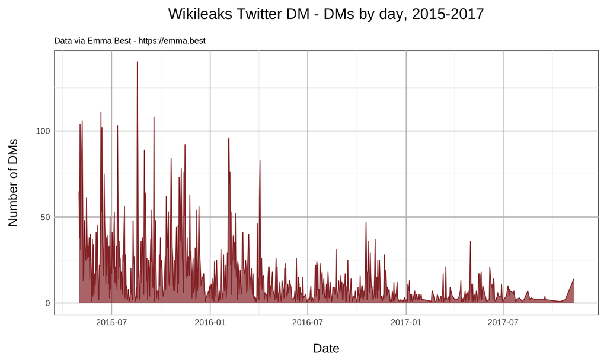

## DMs by year

3 datasets (1 per year), each with 3 columns:

- text: extracted text
- date: date of the dm
- user: user who sent the dm

### 2015

#### 2015.csv

|  | text | date | user |
| --- | --- | --- | --- |
| 1 | group Dm on Wls related trolls activity, incoming events &amp; general topics. | 2015-05-01T13:52:11Z | noll |
| 2 | There’s a race on now to ‘spoil’ our new submission system beta. | 2015-05-01T13:53:39Z | WikiLeaks |
| 3 | Greenberg, who palled up with the openleaks people, launched an attack on wired. Annoying if that framing starts to spread. Verge… | 2015-05-01T13:55:02Z | WikiLeaks |
| 4 | ..stripped the hostility. We’re putting out a statement to soon. The interplay will be surprised by the election in the UK and the weekend. | 2015-05-01T13:55:53Z | WikiLeaks |
| 5 | suppressed. | 2015-05-01T13:56:03Z | WikiLeaks |
| 6 | yes, both Wired &amp; Verge contained DDB’s line of attack. how anyone could fall for OL says it all. expect submissions portal will face – | 2015-05-01T14:01:26Z | noll |
| 7 | – cyber attacks. must be one of, if not the most scrutinized area of cyberspace atm. | 2015-05-01T14:02:37Z | noll |
| 8 | Greenberg is a partisan. Fraudulent to quote the narrative of such people without mentioning the OpenLeaks vaporware plot. | 2015-05-01T14:03:55Z | WikiLeaks |
| 9 | [Tweet] https://twitter.com/m_cetera/status/594197325729378304 the OL ‘quote’ manages to contradict itself w/i three lines. which seems indicative of DDB. | 2015-05-01T14:29:48Z | noll |
| 10 | Hi all. More comfortable discussing stuff in here to be honest. | 2015-05-01T14:32:09Z | WISE Up Action |

[output cut: 6617 more lines]

[interactive chart not shown]

**Static plot**

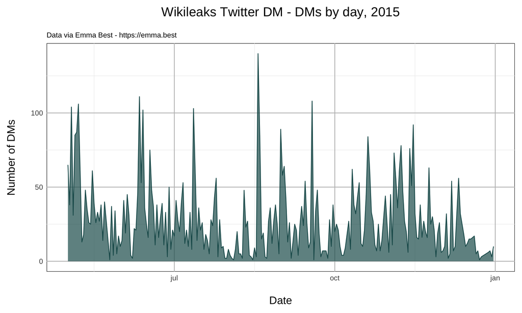

### 2016

#### 2016.csv

|  | text | date | user |
| --- | --- | --- | --- |
| 1 | I think US gov response to WL publications as documented in e-mails court filings, eventually Grand Jury investigation paper trail etc inc the entire legal docs over Manning’s trial etc should one day… | 2016-01-01T00:50:12Z | Emmy B |
| 2 | Anyone know what’s going on with OpManning, Kaidinn and Samurai Lucy? Seeing accusations of doxing, ‘informants’ and the like. Hard to un-pick. | 2016-01-01T07:47:22Z | WISE Up Action |
| 3 | No idea at all | 2016-01-01T09:14:32Z | Emmy B |
| 4 | I have never DM with them that I remember. I’ll take a look tonight. | 2016-01-01T09:17:36Z | Emmy B |
| 5 | HNY everyone. Please stimulate @LouiseMensch into making her JA libels clear so we can sue her. Re: https://twitter.com/search?f=tweets&amp;vertical=default&amp;q=from%3ALouiseMensch%20assange&amp;src… | 2016-01-01T16:53:52Z | WikiLeaks |
| 6 | Mh. Wondering what she means here: https://twitter.com/LouiseMensch/status/682903681621049344 | 2016-01-01T17:22:28Z | voidiss |
| 7 | A love letter, surely. | 2016-01-01T17:27:00Z | WikiLeaks |
| 8 | Haha, LOL! | 2016-01-01T22:44:57Z | voidiss |
| 9 | Mensch has not responded to my tweets to her. Her tweet is about future ‘Ecuador Leaks’ via MGT’s fake forum. I think she has mental health issues or perhaps (she has a history of drug use) is not qui… | 2016-01-03T03:42:05Z | Emmy B |
| 10 | English subtitled version of doc on Russia with JA http://www.liveleak.com/view?i=cf6_1451260176 | 2016-01-03T04:37:31Z | M |

[output cut: 3822 more lines]

[interactive chart not shown]

**Static plot**

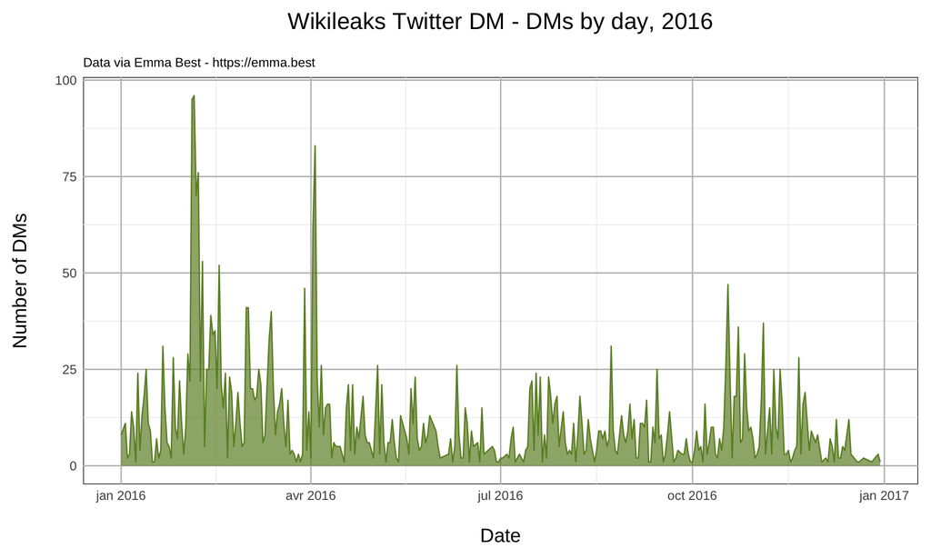

### 2017

#### 2017.csv

|  | text | date | user |
| --- | --- | --- | --- |
| 1 | [Media-image] https://ton.twitter.com/1.1/ton/data/dm/815637525092073476/815637426421043204/GIEievCP.jpg | 2017-01-01T11:15:14Z | WISE Up Action |
| 2 | hahaha | 2017-01-01T11:18:10Z | Emmy B |
| 3 | [Card-summary_large_image] http://www.euractiv.com/section/public-affairs/news/sweden-introduces-pro-whistleblowers-law/ | 2017-01-03T06:57:30Z | WISE Up Action |
| 4 | [Card-summary_large_image] https://www.washingtonpost.com/news/the-fix/wp/2017/01/04/how-some-republicans-learned-to-stop-worrying-and-love-julian-assange/?utm_term=.667dc621f1f4 https://www.washingto… | 2017-01-04T13:00:51Z | WISE Up Action |
| 5 | nice one! 🙂 | 2017-01-04T13:05:53Z | Emmy B |
| 6 | Pence on Trump quoting JA “Healthy sceptisism of president elect towards intelligence services” http://www.thenewstribune.com/news/business/article124444629.html | 2017-01-04T13:36:35Z | Emmy B |
| 7 | Whether it was a horribly mistaken or not, the election clearly showed how angry the average American is with the Washington power structure. Even if Trump’s a narcissistic moron, I was still relieved… | 2017-01-04T13:43:17Z | LibertarianLibrarian |
| 8 | Lovely to see you are back Jenny &lt;3 | 2017-01-04T13:47:05Z | Emmy B |
| 9 | Do you think we should start a petition to Trump to pardon Chelsea Manning? The world is topsy turvy, could he do it? | 2017-01-04T13:48:00Z | Emmy B |
| 10 | Trump could do it. He basically is focused on his own celebrity. Appeal to that. But I suspect that like Obama, he’ll be controlled. | 2017-01-04T14:02:01Z | LibertarianLibrarian |

[output cut: 678 more lines]

[interactive chart not shown]

**Static plot**

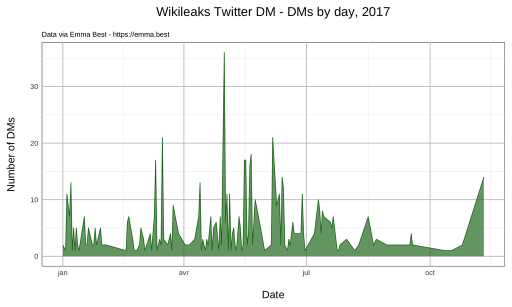

## Methodology

Everything has been done in R.

Methodology is described in methodo

colinfay.me • [@_colinfay](https://twitter.com/_ColinFay)